# TP_3_analyse_multivariee

```python
import numpy as np
import pandas as pd
import geopandas as gpd
import matplotlib.pyplot as plt
```

### Chargement des contours des pays

```python
countries = gpd.read_file("countries.geojson")
```

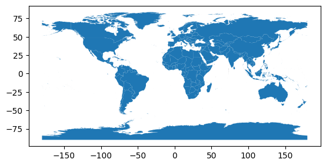

```python
countries.plot()
```

```python
countries
```

|  | name | ISO3166-1-Alpha-3 | ISO3166-1-Alpha-2 | geometry |
| --- | --- | --- | --- | --- |
| 0 | Indonesia | IDN | ID | MULTIPOLYGON (((117.70361 4.16342, 117.70361 4... |
| 1 | Malaysia | MYS | MY | MULTIPOLYGON (((117.70361 4.16342, 117.69711 4... |
| 2 | Chile | CHL | CL | MULTIPOLYGON (((-69.51009 -17.50659, -69.50611... |
| 3 | Bolivia | BOL | BO | POLYGON ((-69.51009 -17.50659, -69.51009 -17.5... |
| 4 | Peru | PER | PE | MULTIPOLYGON (((-69.51009 -17.50659, -69.63832... |
| ... | ... | ... | ... | ... |
| 253 | Macao S.A.R | MAC | MO | MULTIPOLYGON (((113.5586 22.16303, 113.56943 2... |
| 254 | Ashmore and Cartier Islands | -99 | -99 | POLYGON ((123.59702 -12.42832, 123.59775 -12.4... |
| 255 | Bajo Nuevo Bank (Petrel Is.) | -99 | -99 | POLYGON ((-79.98929 15.79495, -79.98782 15.796... |
| 256 | Serranilla Bank | -99 | -99 | POLYGON ((-78.63707 15.86209, -78.64041 15.864... |
| 257 | Scarborough Reef | -99 | -99 | POLYGON ((117.75389 15.15437, 117.75569 15.151... |

258 rows × 4 columns

On assigne la colonne "name" comme index de la couche des pays

```python
countries = countries.set_index("name")
```

Les noms ne correspondent pas à ceux dans les données téléchargées sur Our World in Data, on va les renommer

```python
countries = countries.rename(index={
    "United States of America": "United States",
    "Democratic Republic of the Congo": "Democratic Republic of Congo",
    "Ivory Coast": "Cote d\'Ivoire",
    "Republic of the Congo": "Congo",
    "Czech Republic": "Czechia",
    "The Bahamas": "Bahamas",
    "Guinea Bissau": "Guinea-Bissau",
    "Federated States of Micronesia": "Micronesia (country)",
    "Macedonia": "North Macedonia",
    "eSwatini": "Eswatini",
    "Republic of Serbia": "Serbia",
    "United Republic of Tanzania": "Tanzania",
    "São Tomé and Principe": "Sao Tome and Principe",
    "Cape Verde": "Cabo Verde"
}
)
```

### Chargement des données

#### Cas 1: On a téléchargé des données pour une seule date

```python
life_expectancy = pd.read_csv("life-expectancy.csv")
```

```python
life_expectancy.head()
```

|  | Entity | Code | Year | Period life expectancy at birth | time |
| --- | --- | --- | --- | --- | --- |
| 0 | Afghanistan | AFG | 2023 | 66.0346 | 2023 |
| 1 | Albania | ALB | 2023 | 79.6019 | 2023 |
| 2 | Algeria | DZA | 2023 | 76.2610 | 2023 |
| 3 | Andorra | AND | 2023 | 84.0406 | 2023 |
| 4 | Angola | AGO | 2023 | 64.6170 | 2023 |

```python
life_expectancy = life_expectancy.set_index("Entity")
```

```python
life_expectancy.head()
```

| Entity | Code | Year | Period life expectancy at birth | time |
| --- | --- | --- | --- | --- |
| Afghanistan | AFG | 2023 | 66.0346 | 2023 |
| Albania | ALB | 2023 | 79.6019 | 2023 |
| Algeria | DZA | 2023 | 76.2610 | 2023 |
| Andorra | AND | 2023 | 84.0406 | 2023 |
| Angola | AGO | 2023 | 64.6170 | 2023 |

```python
countries["life_expectancy"]=np.arange(len(countries))
countries.head()
```

| name | ISO3166-1-Alpha-3 | ISO3166-1-Alpha-2 | geometry | life_expectancy |
| --- | --- | --- | --- | --- |
| Indonesia | IDN | ID | MULTIPOLYGON (((117.70361 4.16342, 117.70361 4... | 0 |
| Malaysia | MYS | MY | MULTIPOLYGON (((117.70361 4.16342, 117.69711 4... | 1 |
| Chile | CHL | CL | MULTIPOLYGON (((-69.51009 -17.50659, -69.50611... | 2 |
| Bolivia | BOL | BO | POLYGON ((-69.51009 -17.50659, -69.51009 -17.5... | 3 |
| Peru | PER | PE | MULTIPOLYGON (((-69.51009 -17.50659, -69.63832... | 4 |

```python
life_expectancy["Period life expectancy at birth"]
```

| Entity | Period life expectancy at birth |
| --- | --- |
| Afghanistan | 66.0346 |
| Albania | 79.6019 |
| Algeria | 76.2610 |
| Andorra | 84.0406 |
| Angola | 64.6170 |
| ... | ... |
| Vietnam | 74.5883 |
| Western Sahara | 71.3850 |
| Yemen | 69.2952 |
| Zambia | 66.3487 |
| Zimbabwe | 62.7748 |

201 rows × 1 columns

**dtype:** float64

```python
countries["life_expectancy"]=life_expectancy["Period life expectancy at birth"]
countries.head()
```

| name | ISO3166-1-Alpha-3 | ISO3166-1-Alpha-2 | geometry | life_expectancy |
| --- | --- | --- | --- | --- |
| Indonesia | IDN | ID | MULTIPOLYGON (((117.70361 4.16342, 117.70361 4... | 71.1457 |
| Malaysia | MYS | MY | MULTIPOLYGON (((117.70361 4.16342, 117.69711 4... | 76.6571 |
| Chile | CHL | CL | MULTIPOLYGON (((-69.51009 -17.50659, -69.50611... | 81.1667 |
| Bolivia | BOL | BO | POLYGON ((-69.51009 -17.50659, -69.51009 -17.5... | 68.5814 |
| Peru | PER | PE | MULTIPOLYGON (((-69.51009 -17.50659, -69.63832... | 77.7401 |

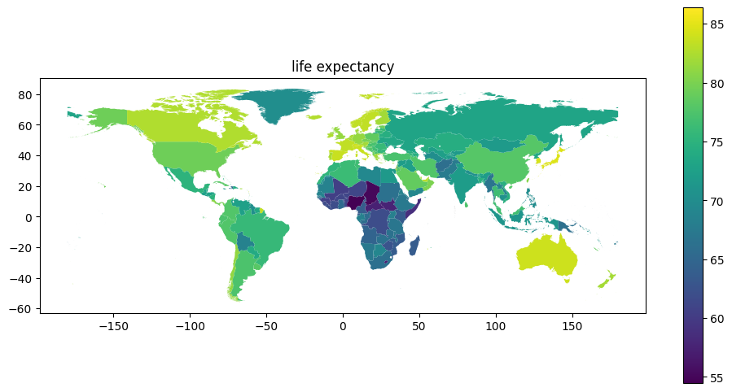

```python
countries.plot(column="life_expectancy", figsize=(12,6), legend=True).set_title("life expectancy")
```

On fait la même chose pour les autres variables étudiées

```python
countries["population"] = pd.read_csv("population.csv").set_index("Entity")["Population (historical)"]
```

```python
countries["log_population"] = np.log10(countries["population"])
```

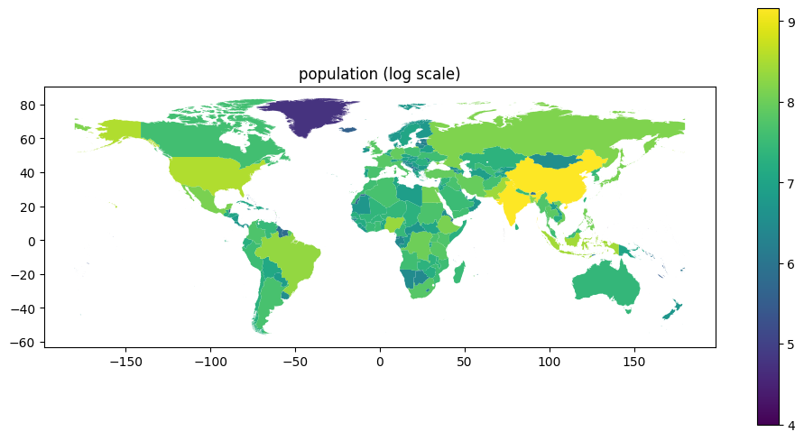

```python
countries.plot(column="log_population", figsize=(12,6), legend=True).set_title("population (log scale)")
```

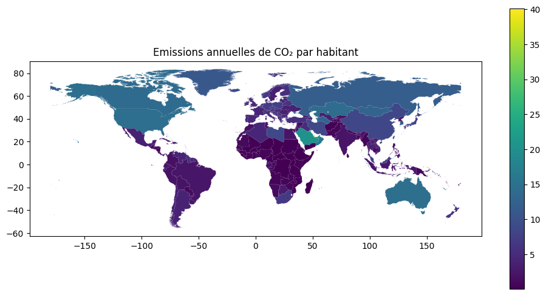

```python
countries["co2_emissions"] = pd.read_csv("co-emissions-per-capita.csv").set_index("Entity")["Annual CO₂ emissions (per capita)"]
countries.plot(column="co2_emissions", figsize=(12,6), legend=True).set_title("Emissions annuelles de CO₂ par habitant")
```

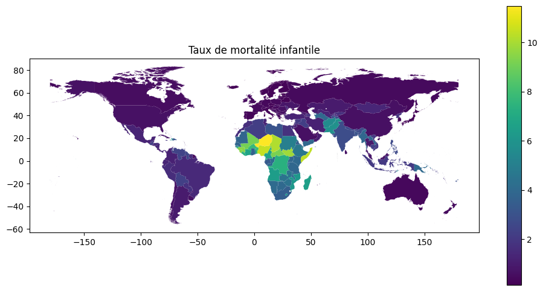

```python
countries["child_mortality"] = pd.read_csv("child-mortality.csv").set_index("Entity")["Child mortality rate"]
countries.plot(column="child_mortality", figsize=(12,6), legend=True).set_title("Taux de mortalité infantile")
```

#### Cas 2 : on a téléchargé la série temporelle

```python
hdi = pd.read_csv("human-development-index.csv")
```

```python
hdi.head()
```

|  | Entity | Code | Year | Human Development Index | World regions according to OWID |
| --- | --- | --- | --- | --- | --- |
| 0 | Afghanistan | AFG | 1990 | 0.285 | NaN |
| 1 | Afghanistan | AFG | 1991 | 0.291 | NaN |
| 2 | Afghanistan | AFG | 1992 | 0.301 | NaN |
| 3 | Afghanistan | AFG | 1993 | 0.311 | NaN |
| 4 | Afghanistan | AFG | 1994 | 0.305 | NaN |

```python
hdi_by_year = hdi.pivot_table(index='Entity', columns='Year', values='Human Development Index')
hdi_by_year.head()
```

| Year Entity | 1990 | 1991 | 1992 | 1993 | 1994 | 1995 | 1996 | 1997 | 1998 | 1999 | ... | 2014 | 2015 | 2016 | 2017 | 2018 | 2019 | 2020 | 2021 | 2022 | 2023 |
| --- | --- | --- | --- | --- | --- | --- | --- | --- | --- | --- | --- | --- | --- | --- | --- | --- | --- | --- | --- | --- | --- |
| Afghanistan | 0.285 | 0.291 | 0.301 | 0.311 | 0.305 | 0.329 | 0.334 | 0.338 | 0.338 | 0.347 | ... | 0.497000 | 0.49600 | 0.495000 | 0.4960 | 0.498000 | 0.507000 | 0.501000 | 0.486000 | 0.495000 | 0.496000 |
| Africa | NaN | NaN | NaN | NaN | NaN | NaN | NaN | NaN | NaN | NaN | ... | 0.536723 | 0.54259 | 0.546639 | 0.5504 | 0.555833 | 0.560354 | 0.559465 | 0.561104 | 0.571485 | 0.576059 |
| Albania | 0.654 | 0.638 | 0.622 | 0.624 | 0.629 | 0.638 | 0.647 | 0.645 | 0.659 | 0.671 | ... | 0.797000 | 0.79700 | 0.797000 | 0.7980 | 0.801000 | 0.805000 | 0.794000 | 0.794000 | 0.806000 | 0.810000 |
| Algeria | 0.595 | 0.596 | 0.601 | 0.603 | 0.603 | 0.608 | 0.615 | 0.624 | 0.634 | 0.643 | ... | 0.732000 | 0.73700 | 0.743000 | 0.7460 | 0.749000 | 0.753000 | 0.742000 | 0.755000 | 0.761000 | 0.763000 |
| Andorra | NaN | NaN | NaN | NaN | NaN | NaN | NaN | NaN | NaN | NaN | ... | 0.866000 | 0.86900 | 0.872000 | 0.8730 | 0.875000 | 0.876000 | 0.851000 | 0.871000 | 0.893000 | 0.913000 |

5 rows × 34 columns

```python
def function_to_rename_columns_name(column_name):
    return f"hdi_{column_name}"

hdi_by_year = hdi_by_year.rename(columns=function_to_rename_columns_name)
hdi_by_year.head()
```

| Year Entity | hdi_1990 | hdi_1991 | hdi_1992 | hdi_1993 | hdi_1994 | hdi_1995 | hdi_1996 | hdi_1997 | hdi_1998 | hdi_1999 | ... | hdi_2014 | hdi_2015 | hdi_2016 | hdi_2017 | hdi_2018 | hdi_2019 | hdi_2020 | hdi_2021 | hdi_2022 | hdi_2023 |
| --- | --- | --- | --- | --- | --- | --- | --- | --- | --- | --- | --- | --- | --- | --- | --- | --- | --- | --- | --- | --- | --- |
| Afghanistan | 0.285 | 0.291 | 0.301 | 0.311 | 0.305 | 0.329 | 0.334 | 0.338 | 0.338 | 0.347 | ... | 0.497000 | 0.49600 | 0.495000 | 0.4960 | 0.498000 | 0.507000 | 0.501000 | 0.486000 | 0.495000 | 0.496000 |
| Africa | NaN | NaN | NaN | NaN | NaN | NaN | NaN | NaN | NaN | NaN | ... | 0.536723 | 0.54259 | 0.546639 | 0.5504 | 0.555833 | 0.560354 | 0.559465 | 0.561104 | 0.571485 | 0.576059 |
| Albania | 0.654 | 0.638 | 0.622 | 0.624 | 0.629 | 0.638 | 0.647 | 0.645 | 0.659 | 0.671 | ... | 0.797000 | 0.79700 | 0.797000 | 0.7980 | 0.801000 | 0.805000 | 0.794000 | 0.794000 | 0.806000 | 0.810000 |
| Algeria | 0.595 | 0.596 | 0.601 | 0.603 | 0.603 | 0.608 | 0.615 | 0.624 | 0.634 | 0.643 | ... | 0.732000 | 0.73700 | 0.743000 | 0.7460 | 0.749000 | 0.753000 | 0.742000 | 0.755000 | 0.761000 | 0.763000 |
| Andorra | NaN | NaN | NaN | NaN | NaN | NaN | NaN | NaN | NaN | NaN | ... | 0.866000 | 0.86900 | 0.872000 | 0.8730 | 0.875000 | 0.876000 | 0.851000 | 0.871000 | 0.893000 | 0.913000 |

5 rows × 34 columns

```python
hdi_by_year.isna().sum(axis=0)
```

| Year | 0 |
| --- | --- |
| hdi_1990 | 60 |
| hdi_1991 | 60 |
| hdi_1992 | 60 |
| hdi_1993 | 59 |
| hdi_1994 | 59 |
| hdi_1995 | 51 |
| hdi_1996 | 51 |
| hdi_1997 | 51 |
| hdi_1998 | 51 |
| hdi_1999 | 46 |
| hdi_2000 | 24 |
| hdi_2001 | 24 |
| hdi_2002 | 23 |
| hdi_2003 | 22 |
| hdi_2004 | 20 |
| hdi_2005 | 7 |
| hdi_2006 | 7 |
| hdi_2007 | 6 |
| hdi_2008 | 5 |
| hdi_2009 | 6 |
| hdi_2010 | 2 |
| hdi_2011 | 1 |
| hdi_2012 | 1 |
| hdi_2013 | 1 |
| hdi_2014 | 1 |
| hdi_2015 | 1 |
| hdi_2016 | 1 |
| hdi_2017 | 1 |
| hdi_2018 | 1 |
| hdi_2019 | 1 |
| hdi_2020 | 1 |
| hdi_2021 | 1 |
| hdi_2022 | 1 |
| hdi_2023 | 0 |

**dtype:** int64

```python
countries[["hdi_2023", "hdi_2013"]]=hdi_by_year[["hdi_2023", "hdi_2013"]]
```

```python
countries
```

| name | ISO3166-1-Alpha-3 | ISO3166-1-Alpha-2 | geometry | life_expectancy | population | log_population | child_mortality | co2_emissions | hdi_2023 | hdi_2013 |
| --- | --- | --- | --- | --- | --- | --- | --- | --- | --- | --- |
| Indonesia | IDN | ID | MULTIPOLYGON (((117.70361 4.16342, 117.70361 4... | 71.1457 | 281190068.0 | 8.449000 | 2.06 | 2.711182 | 0.728 | 0.690 |
| Malaysia | MYS | MY | MULTIPOLYGON (((117.70361 4.16342, 117.69711 4... | 76.6571 | 35126295.0 | 7.545632 | 0.81 | 7.865810 | 0.819 | 0.791 |
| Chile | CHL | CL | MULTIPOLYGON (((-69.51009 -17.50659, -69.50611... | 81.1667 | 19658833.0 | 7.293558 | 0.72 | 3.947550 | 0.878 | 0.845 |
| Bolivia | BOL | BO | POLYGON ((-69.51009 -17.50659, -69.51009 -17.5... | 68.5814 | 12244161.0 | 7.087929 | 2.31 | 2.010797 | 0.733 | 0.699 |
| Peru | PER | PE | MULTIPOLYGON (((-69.51009 -17.50659, -69.63832... | 77.7401 | 33845616.0 | 7.529502 | 1.58 | 1.951944 | 0.794 | 0.757 |
| ... | ... | ... | ... | ... | ... | ... | ... | ... | ... | ... |
| Macao S.A.R | MAC | MO | MULTIPOLYGON (((113.5586 22.16303, 113.56943 2... | NaN | NaN | NaN | NaN | NaN | NaN | NaN |
| Ashmore and Cartier Islands | -99 | -99 | POLYGON ((123.59702 -12.42832, 123.59775 -12.4... | NaN | NaN | NaN | NaN | NaN | NaN | NaN |
| Bajo Nuevo Bank (Petrel Is.) | -99 | -99 | POLYGON ((-79.98929 15.79495, -79.98782 15.796... | NaN | NaN | NaN | NaN | NaN | NaN | NaN |
| Serranilla Bank | -99 | -99 | POLYGON ((-78.63707 15.86209, -78.64041 15.864... | NaN | NaN | NaN | NaN | NaN | NaN | NaN |
| Scarborough Reef | -99 | -99 | POLYGON ((117.75389 15.15437, 117.75569 15.151... | NaN | NaN | NaN | NaN | NaN | NaN | NaN |

258 rows × 10 columns

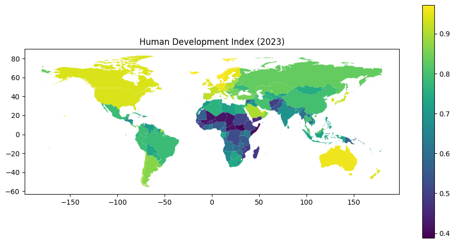

```python
countries.plot(column='hdi_2023', figsize=(12,6), legend=True).set_title("Human Development Index (2023)")
```

#### Gestion des valeurs NaN

La plupart des méthodes d'analyse statistiques ne supportent pas les NaN, par exemple l'ACP.

Si l'analyse de ces unités spatiales est importante, on peut leur attribuer une valeur, par exemple la moyenne pour chaque variable. Si les variables avec un NaN sont corrélées avec une variable pour laquelle la valeur est connue, on peut inférer avec une régression linéaire.

Dans notre cas, on va simplement ignorer les individus avec des NaN, avec la méthode `dropna()`.

```python
countries = countries.dropna()
countries
```

| name | ISO3166-1-Alpha-3 | ISO3166-1-Alpha-2 | geometry | life_expectancy | population | log_population | child_mortality | co2_emissions | hdi_2023 | hdi_2013 |
| --- | --- | --- | --- | --- | --- | --- | --- | --- | --- | --- |
| Indonesia | IDN | ID | MULTIPOLYGON (((117.70361 4.16342, 117.70361 4... | 71.1457 | 281190068.0 | 8.449000 | 2.06 | 2.711182 | 0.728 | 0.690 |
| Malaysia | MYS | MY | MULTIPOLYGON (((117.70361 4.16342, 117.69711 4... | 76.6571 | 35126295.0 | 7.545632 | 0.81 | 7.865810 | 0.819 | 0.791 |
| Chile | CHL | CL | MULTIPOLYGON (((-69.51009 -17.50659, -69.50611... | 81.1667 | 19658833.0 | 7.293558 | 0.72 | 3.947550 | 0.878 | 0.845 |
| Bolivia | BOL | BO | POLYGON ((-69.51009 -17.50659, -69.51009 -17.5... | 68.5814 | 12244161.0 | 7.087929 | 2.31 | 2.010797 | 0.733 | 0.699 |
| Peru | PER | PE | MULTIPOLYGON (((-69.51009 -17.50659, -69.63832... | 77.7401 | 33845616.0 | 7.529502 | 1.58 | 1.951944 | 0.794 | 0.757 |
| ... | ... | ... | ... | ... | ... | ... | ... | ... | ... | ... |
| Nauru | NRU | NR | POLYGON ((166.93881 -0.49041, 166.95558 -0.497... | 62.1094 | 11900.0 | 4.075547 | 0.89 | 4.933193 | 0.703 | 0.640 |
| Micronesia (country) | FSM | FM | MULTIPOLYGON (((163.02605 5.34089, 163.03045 5... | 67.1983 | 112646.0 | 5.051716 | 2.31 | 1.278669 | 0.615 | 0.603 |
| Vanuatu | VUT | VU | MULTIPOLYGON (((169.84034 -20.1408, 169.86052 ... | 71.4769 | 320422.0 | 5.505722 | 1.68 | 0.588156 | 0.621 | 0.592 |
| Palau | PLW | PW | MULTIPOLYGON (((134.2715 7.07453, 134.27931 7.... | 69.2690 | 17751.0 | 4.249223 | 2.23 | 12.180102 | 0.786 | 0.791 |
| Bahrain | BHR | BH | MULTIPOLYGON (((50.55161 26.19424, 50.59474 26... | 81.2835 | 1569674.0 | 6.195809 | 0.86 | 24.710030 | 0.899 | 0.846 |

186 rows × 10 columns

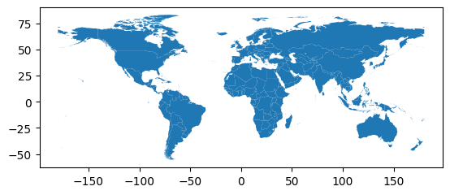

```python
countries.plot()
```

### Exploration du jeu

```python
countries.describe()# Affiche des statistiques univariées pour chaque variable
```

|  | life_expectancy | population | log_population | child_mortality | co2_emissions | hdi_2023 | hdi_2013 |
| --- | --- | --- | --- | --- | --- | --- | --- |
| count | 186.000000 | 1.860000e+02 | 186.000000 | 186.000000 | 186.000000 | 186.000000 | 186.000000 |
| mean | 73.048182 | 4.303034e+07 | 6.854228 | 2.478011 | 4.360875 | 0.740656 | 0.710382 |
| std | 7.025400 | 1.534759e+08 | 0.937179 | 2.469786 | 5.568655 | 0.150070 | 0.154175 |
| min | 54.462300 | 9.837000e+03 | 3.992863 | 0.210000 | 0.055592 | 0.388000 | 0.359000 |
| 25% | 67.450850 | 2.538054e+06 | 6.404222 | 0.610000 | 0.808994 | 0.621250 | 0.583250 |
| 50% | 73.456050 | 9.495406e+06 | 6.977426 | 1.560000 | 2.862610 | 0.762500 | 0.739000 |
| 75% | 78.125250 | 3.354244e+07 | 7.525590 | 3.845000 | 5.346318 | 0.856750 | 0.829250 |
| max | 84.712300 | 1.438070e+09 | 9.157780 | 11.480000 | 40.127865 | 0.972000 | 0.953000 |

[output not shown]

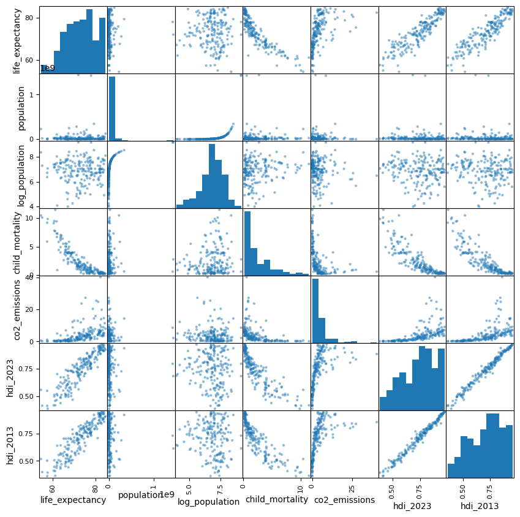

```python
pd.plotting.scatter_matrix(countries, figsize=(10, 10))
```

```python
countries.iloc[:,3:].corr()#J'enlève les colones de code et de géométrie pour calculer les corrélations
```

|  | life_expectancy | population | log_population | child_mortality | co2_emissions | hdi_2023 | hdi_2013 |
| --- | --- | --- | --- | --- | --- | --- | --- |
| life_expectancy | 1.000000 | 0.014349 | -0.002132 | -0.877801 | 0.481439 | 0.904435 | 0.900622 |
| population | 0.014349 | 1.000000 | 0.441910 | -0.003487 | 0.010886 | -0.011176 | -0.038145 |
| log_population | -0.002132 | 0.441910 | 1.000000 | 0.148135 | -0.071339 | -0.113981 | -0.124327 |
| child_mortality | -0.877801 | -0.003487 | 0.148135 | 1.000000 | -0.421016 | -0.862051 | -0.861931 |
| co2_emissions | 0.481439 | 0.010886 | -0.071339 | -0.421016 | 1.000000 | 0.540600 | 0.538467 |
| hdi_2023 | 0.904435 | -0.011176 | -0.113981 | -0.862051 | 0.540600 | 1.000000 | 0.987957 |
| hdi_2013 | 0.900622 | -0.038145 | -0.124327 | -0.861931 | 0.538467 | 0.987957 | 1.000000 |

# ACP

Centrer-réduire les variables :

```python
countries_cr = (countries.iloc[:,3:] - countries.iloc[:,3:].mean(axis=0))/countries.iloc[:,3:].std(axis=0)
countries_cr
```

| name | life_expectancy | population | log_population | child_mortality | co2_emissions | hdi_2023 | hdi_2013 |
| --- | --- | --- | --- | --- | --- | --- | --- |
| Indonesia | -0.270801 | 1.551773 | 1.701673 | -0.169250 | -0.296246 | -0.084333 | -0.132199 |
| Malaysia | 0.513696 | -0.051500 | 0.737750 | -0.675366 | 0.629404 | 0.522051 | 0.522902 |
| Chile | 1.155595 | -0.152281 | 0.468779 | -0.711807 | -0.074223 | 0.915201 | 0.873155 |
| Bolivia | -0.635805 | -0.200593 | 0.249366 | -0.068026 | -0.422019 | -0.051016 | -0.073824 |
| Peru | 0.667851 | -0.059845 | 0.720539 | -0.363599 | -0.432587 | 0.355462 | 0.302373 |
| ... | ... | ... | ... | ... | ... | ... | ... |
| Nauru | -1.557033 | -0.280294 | -2.964942 | -0.642975 | 0.102775 | -0.250923 | -0.456507 |
| Micronesia (country) | -0.832676 | -0.279638 | -1.923339 | -0.068026 | -0.553492 | -0.837316 | -0.696494 |
| Vanuatu | -0.223657 | -0.278284 | -1.438899 | -0.323109 | -0.677492 | -0.797335 | -0.767842 |
| Palau | -0.537931 | -0.280256 | -2.779624 | -0.100418 | 1.404150 | 0.302153 | 0.522902 |
| Bahrain | 1.172221 | -0.270145 | -0.702554 | -0.655122 | 3.654232 | 1.055136 | 0.879641 |

186 rows × 7 columns

```python
from sklearn.decomposition import PCA
pca = PCA()
countries_transformed = pca.fit_transform(countries_cr)
countries_transformed
```

```
array([[-0.38782093,  2.2577136 , -0.27033415, ..., -0.1075837 ,
        -0.43054918,  0.01581441],
       [ 1.20067973,  0.5528224 ,  0.16633161, ..., -0.20558946,
        -0.20109657,  0.00503812],
       [ 1.67981178,  0.33923759, -0.67661612, ...,  0.11003823,
         0.21270873,  0.02796701],
       ...,
       [-0.82181178, -1.25417263, -0.44619198, ..., -0.78633218,
         0.18600237, -0.02108663],
       [ 0.82865724, -2.15334798,  1.48835281, ...,  0.28458681,
        -0.27605793, -0.14799218],
       [ 2.97659196, -0.46833059,  2.87956824, ..., -0.29321703,
         0.35584879,  0.11548285]])
```

On va remettre countries_transformed dans un geodataframe pour en permettre la visualisation cartographique.

```python
countries_transformed_gdf = gpd.GeoDataFrame(countries_transformed, index=countries.index, geometry=countries.geometry, crs=countries.crs)
countries_transformed_gdf
```

| name | 0 | 1 | 2 | 3 | 4 | 5 | 6 | geometry |
| --- | --- | --- | --- | --- | --- | --- | --- | --- |
| Indonesia | -0.387821 | 2.257714 | -0.270334 | -0.008092 | -0.107584 | -0.430549 | 0.015814 | MULTIPOLYGON (((117.70361 4.16342, 117.70361 4... |
| Malaysia | 1.200680 | 0.552822 | 0.166332 | -0.592792 | -0.205589 | -0.201097 | 0.005038 | MULTIPOLYGON (((117.70361 4.16342, 117.69711 4... |
| Chile | 1.679812 | 0.339238 | -0.676616 | -0.487564 | 0.110038 | 0.212709 | 0.027967 | MULTIPOLYGON (((-69.51009 -17.50659, -69.50611... |
| Bolivia | -0.473525 | -0.034564 | -0.311355 | -0.194320 | 0.045559 | -0.577952 | 0.034945 | POLYGON ((-69.51009 -17.50659, -69.51009 -17.5... |
| Peru | 0.613848 | 0.518250 | -0.737999 | -0.537023 | -0.034877 | 0.158002 | 0.035943 | MULTIPOLYGON (((-69.51009 -17.50659, -69.63832... |
| ... | ... | ... | ... | ... | ... | ... | ... | ... |
| Nauru | -0.535845 | -2.413022 | 0.479206 | 2.095558 | -0.443317 | -1.015918 | 0.172378 | POLYGON ((166.93881 -0.49041, 166.95558 -0.497... |
| Micronesia (country) | -1.136291 | -1.647075 | -0.119571 | 1.298190 | -0.484725 | -0.144627 | -0.092071 | MULTIPOLYGON (((163.02605 5.34089, 163.03045 5... |
| Vanuatu | -0.821812 | -1.254173 | -0.446192 | 0.941192 | -0.786332 | 0.186002 | -0.021087 | MULTIPOLYGON (((169.84034 -20.1408, 169.86052 ... |
| Palau | 0.828657 | -2.153348 | 1.488353 | 1.650089 | 0.284587 | -0.276058 | -0.147992 | MULTIPOLYGON (((134.2715 7.07453, 134.27931 7.... |
| Bahrain | 2.976592 | -0.468331 | 2.879568 | -0.114218 | -0.293217 | 0.355849 | 0.115483 | MULTIPOLYGON (((50.55161 26.19424, 50.59474 26... |

186 rows × 8 columns

Taux de variance expliqué cumulé

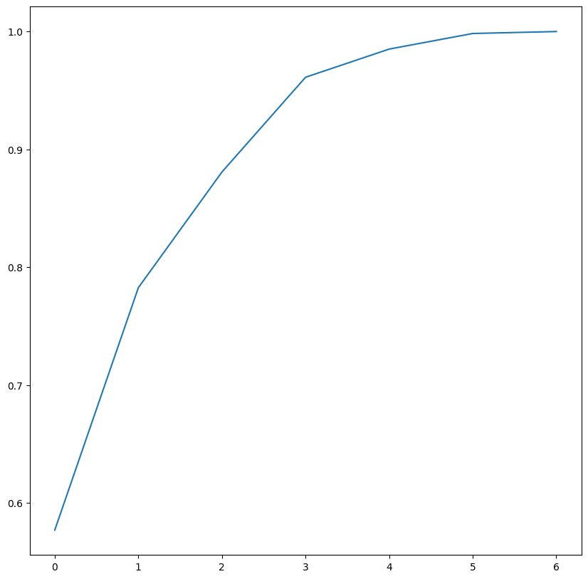

```python
plt.figure(figsize=(10,10))
plt.plot(np.cumsum(pca.explained_variance_ratio_))
```

Là par exemple, la première composante principale explique environ 60% de la variance, et la somme des 3 premières environ 90%. Si on garde 3 composantes, on garde "90% de l'information" en n'utilisant que 3 variables au lieu de 7.

```python
pca.components_[0]
```

```
array([ 0.46899691, -0.0141802 , -0.06995472, -0.45681452,  0.31120297,
        0.48464288,  0.484295  ])
```

La première composante oppose l'esperance de vie, les emissions de CO2 et l'hdi au 2 dates d'un côté à la mortalité infantile.

```python
pca.components_[1]
```

```
array([ 0.08856495,  0.70726013,  0.7007067 , -0.00339905,  0.02488523,
        0.01782879, -0.00088282])
```

La deuxième se concentre surtout sur la population et log population

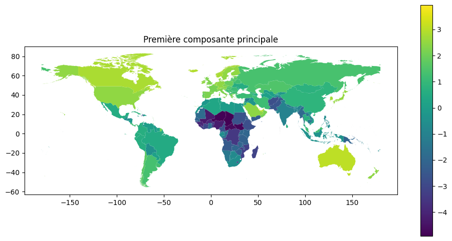

```python
countries_transformed_gdf.plot(column=0, figsize=(12,6), legend=True).set_title("Première composante principale")
```

On voit que les pays equatoriaux sont associés avec une faible valeur de la première CP, c'est-à-dire à une faible espérance de vie et un faible hdi, et un taux de mortalité infantile plus élevé.

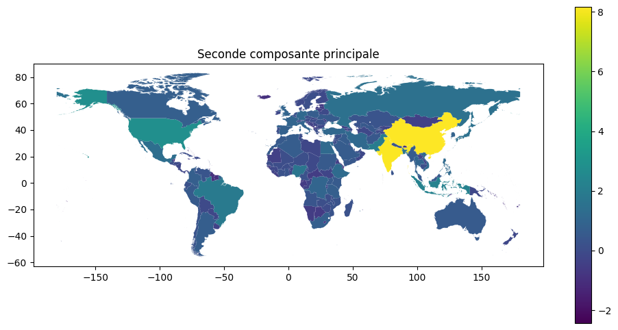

```python
countries_transformed_gdf.plot(column=1, figsize=(12,6), legend=True).set_title("Seconde composante principale")
```

Avec cette composante principale, des pays comme l'Inde ou la Chine ont des valeurs élevées parce qu'elles ont une population importante.

Valeurs pour la France :

```python
countries_transformed_gdf.loc["France"]
```

|  | France |
| --- | --- |
| 0 | 2.136315 |
| 1 | 0.983079 |
| 2 | -0.820932 |
| 3 | -0.693335 |
| 4 | 0.250692 |
| 5 | 0.224911 |
| 6 | -0.013748 |
| geometry | MULTIPOLYGON (((-54.111527 2.11427, -54.134908... |

**dtype:** object

La France a une valeur positive pour la première CP, donc elle a plutôt une bonne espérance de vie, un haut taux d'emissions de CO2... Elle a une valeur au dessus de 0 pour la 2ème CP, mais pas très haute : elle est un peu plus peuplée que la moyenne (68 millions vs 43 millions d'habitants)

Calculer la corrélation entre une variable et une composante principale

```python
np.corrcoef(countries_cr["life_expectancy"], countries_transformed_gdf[0])
```

```
array([[1.        , 0.94254968],
       [0.94254968, 1.        ]])
```

On peut vérifier que c'est la même valeur qu'obtenu avec la formule suivante :

```python
pca.components_[0][0] * np.sqrt(pca.explained_variance_[0])
```

```
np.float64(0.9425496753669508)
```

Cercle des corrélations

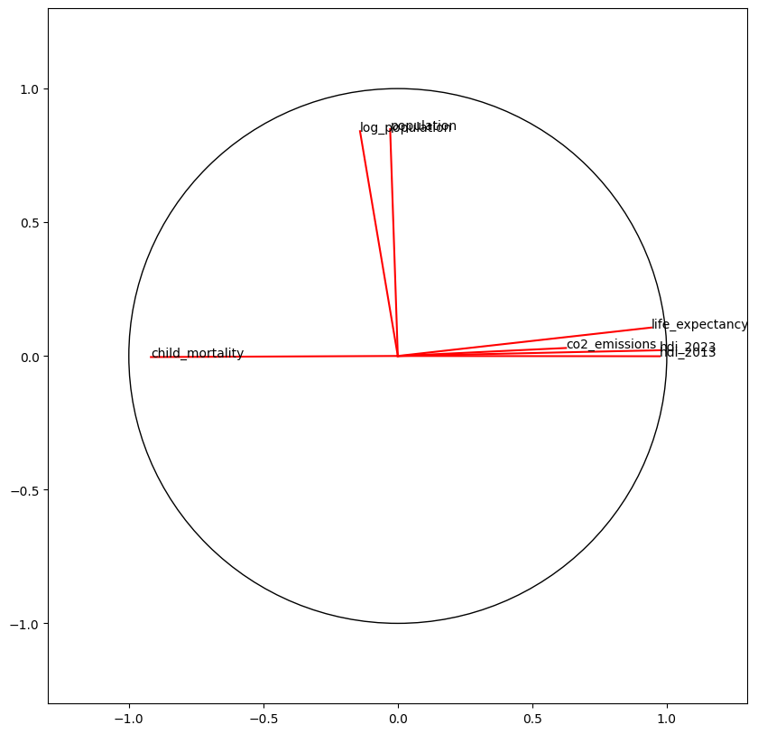

```python
plt.figure(figsize =(10, 10))
ax = plt.subplot()
plt.xlim(-1.3,1.3)
plt.ylim(-1.3,1.3)
ax.add_patch(plt.Circle((0, 0), radius = 1, color='black', fill=False))
for i, variable in enumerate(list(countries_cr.columns)):
    plt.plot([0, pca.components_[0][i] * np.sqrt(pca.explained_variance_[0])], [0, pca.components_[1][i] * np.sqrt(pca.explained_variance_[1])], color='red')
    plt.text(pca.components_[0][i] * np.sqrt(pca.explained_variance_[0]), pca.components_[1][i] * np.sqrt(pca.explained_variance_[1]), variable)
```

On retrouve les interprétations faites précédemments :

- Les variables hdi 2013 et 2023, l'esperance de vie et les emissions sont corrélées entre elles
- Elles ne sont pas corrélées à la population (angle proche de 90°)
- Elles ont une corrélation négatives avec la mortalité infantile

## Classification non supervisée

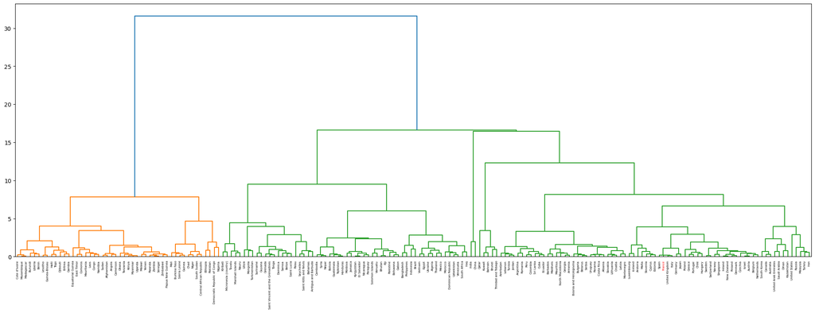

```python
from scipy.cluster.hierarchy import dendrogram, linkage
Z = linkage(countries_transformed_gdf.iloc[:,:3], 'ward')#Sur les 3 premières composantes de l'ACP
plt.figure(figsize=(25, 8))
ax=plt.subplot()
dn = dendrogram(Z)

country_names = countries_transformed_gdf.iloc[dn["leaves"]].index
ax.set_xticklabels(country_names, rotation=90)

# Set colors for the tick labels
colors = ["red" if name == "France" else "black" for name in country_names]

# Apply colors to the tick labels
tick_labels = ax.get_xticklabels()
for tick_label, color in zip(tick_labels, colors):
    tick_label.set_color(color)

plt.show()
```

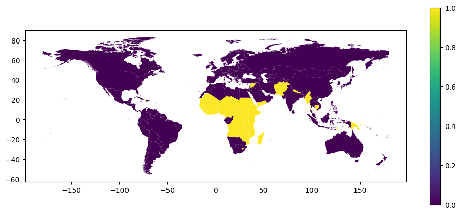

```python
from sklearn.cluster import AgglomerativeClustering

cah = AgglomerativeClustering(n_clusters=2, linkage="ward")
cah_class_2 = cah.fit_predict(countries_cr).astype(int)
cah_class_2 = gpd.GeoDataFrame(pd.Series(cah_class_2, index=countries.index), geometry=countries.geometry)
cah_class_2.plot(column=0, figsize=(12,5), legend=True)
```

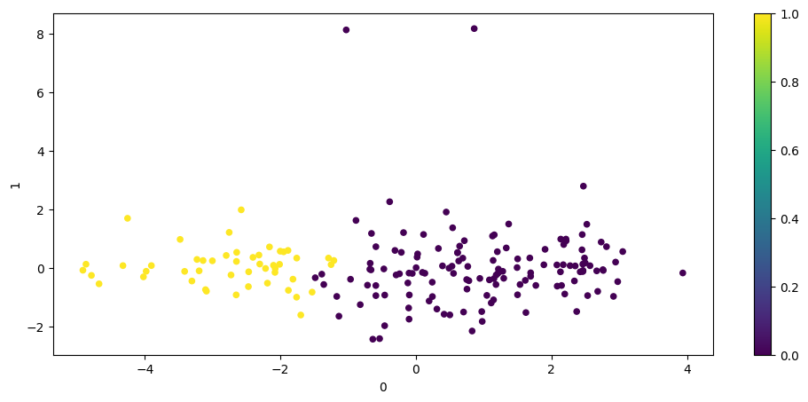

```python
countries_transformed_gdf.plot(kind="scatter", x=0, y=1, c=cah_class_2[0], figsize=(12,5), cmap="viridis")
```

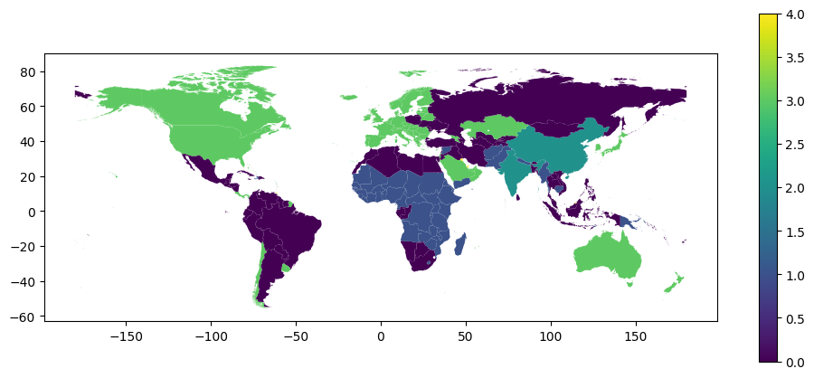

```python
from sklearn.cluster import AgglomerativeClustering

cah = AgglomerativeClustering(n_clusters=5, linkage="ward")
cah_class_5 = cah.fit_predict(countries_cr).astype(int)
cah_class_5 = gpd.GeoDataFrame(pd.Series(cah_class_5, index=countries.index), geometry=countries.geometry)
cah_class_5.plot(column=0, figsize=(12,5), legend=True)
```

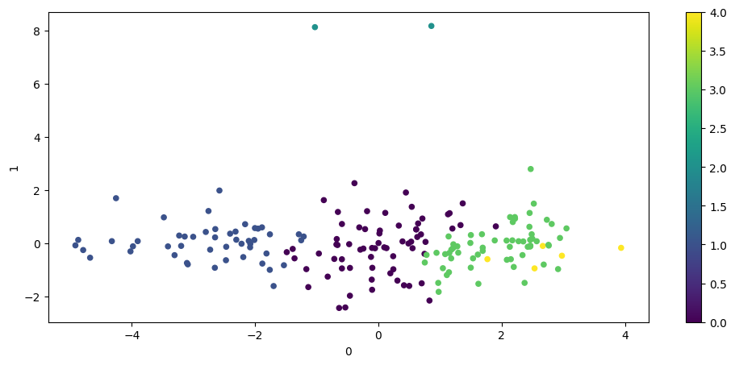

```python
countries_transformed_gdf.plot(kind="scatter", x=0, y=1, c=cah_class_5[0], figsize=(12,5), cmap="viridis")
```

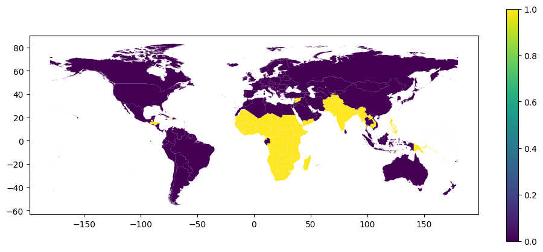

```python
from sklearn.cluster import KMeans

k_means = KMeans(n_clusters=2)
k_means_class_2 = k_means.fit_predict(countries_cr).astype(int)
k_means_class_2 = gpd.GeoDataFrame(pd.Series(k_means_class_2, index=countries.index), geometry=countries.geometry)
k_means_class_2.plot(column=0, figsize=(12,5), legend=True)
```

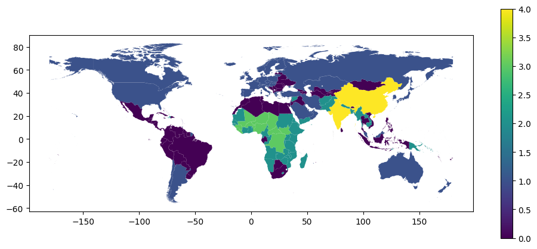

```python
from sklearn.cluster import KMeans

k_means = KMeans(n_clusters=5)
k_means_class_5 = k_means.fit_predict(countries_cr).astype(int)
k_means_class_5 = gpd.GeoDataFrame(pd.Series(k_means_class_5, index=countries.index), geometry=countries.geometry)
k_means_class_5.plot(column=0, figsize=(12,5), legend=True)
```

```python
inertie_totale = ((countries_cr - countries_cr.mean(axis=0))**2).sum().sum()
inertie_totale
```

```
np.float64(1295.0)
```

```python
for i, clustering in enumerate([cah_class_2, k_means_class_2, cah_class_5, k_means_class_5]):
    inertie_inter = 0
    for c in range(max(clustering[0])+1):
        centre_c = countries_cr.loc[clustering[0]==c].mean()
        inertie_inter += ((countries_cr.mean(axis=0) - centre_c)**2).sum().sum()
    Q = inertie_inter / inertie_totale
    print("La qualité du clustering", i, "est", Q)
```

```
La qualité du clustering 0 est 0.006609839407358844
La qualité du clustering 1 est 0.005332036190339916
La qualité du clustering 2 est 0.093074028932465
La qualité du clustering 3 est 0.09009296871477224
```

## Classification supervisée

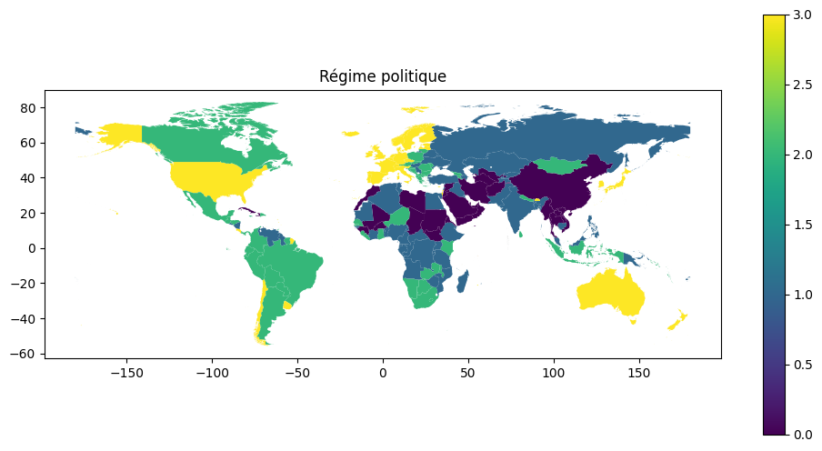

```python
countries["political_regime"] = pd.read_csv("political-regime.csv").set_index("Entity")["Political regime"]
countries.plot(column="political_regime", figsize=(12,6), legend=True).set_title("Régime politique")
```

Quel est le nombre de pays par régime politique ?

```python
countries["political_regime"].value_counts()
```

| political_regime | count |
| --- | --- |
| 2.0 | 53 |
| 1.0 | 53 |
| 3.0 | 33 |
| 0.0 | 28 |

**dtype:** int64

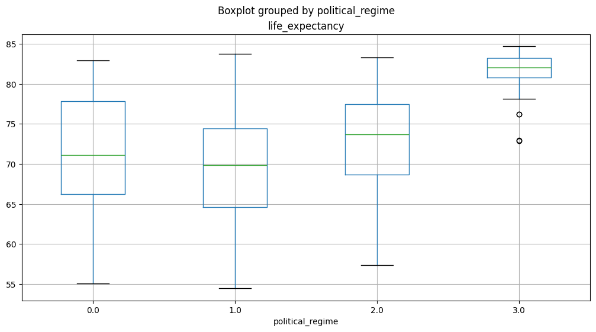

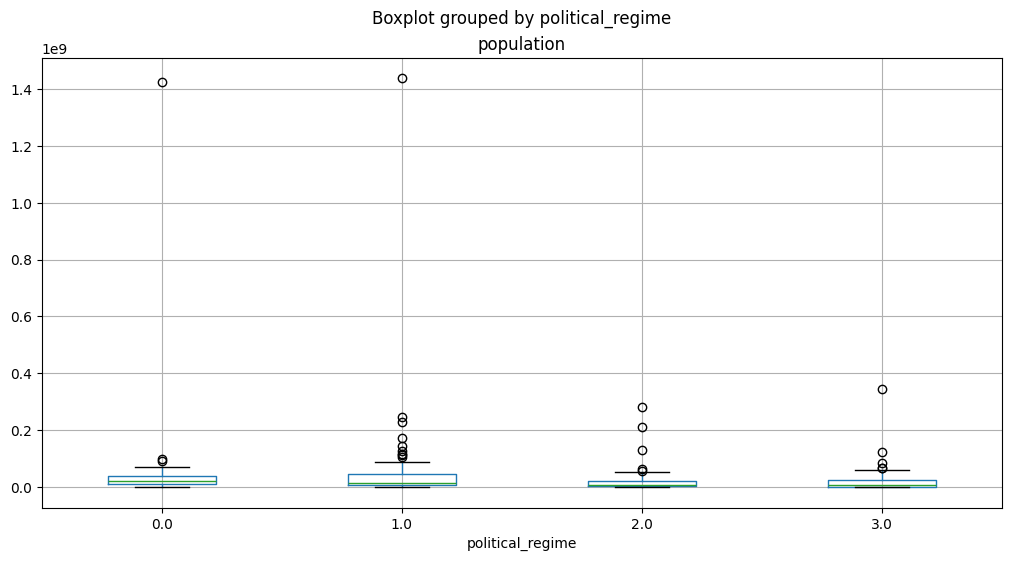

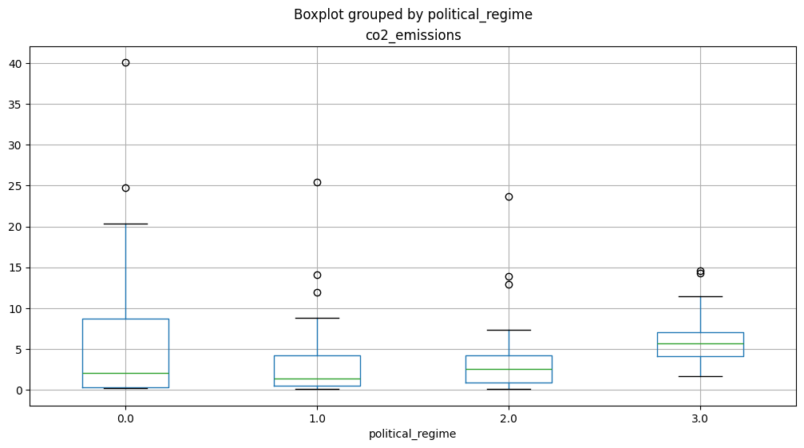

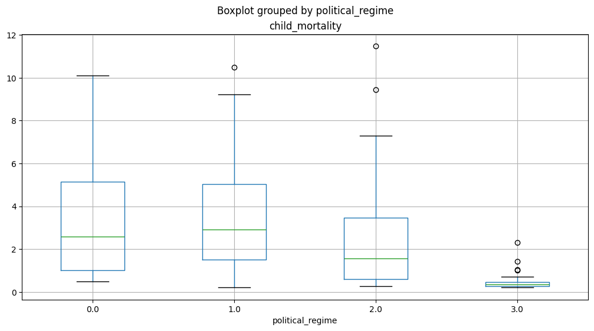

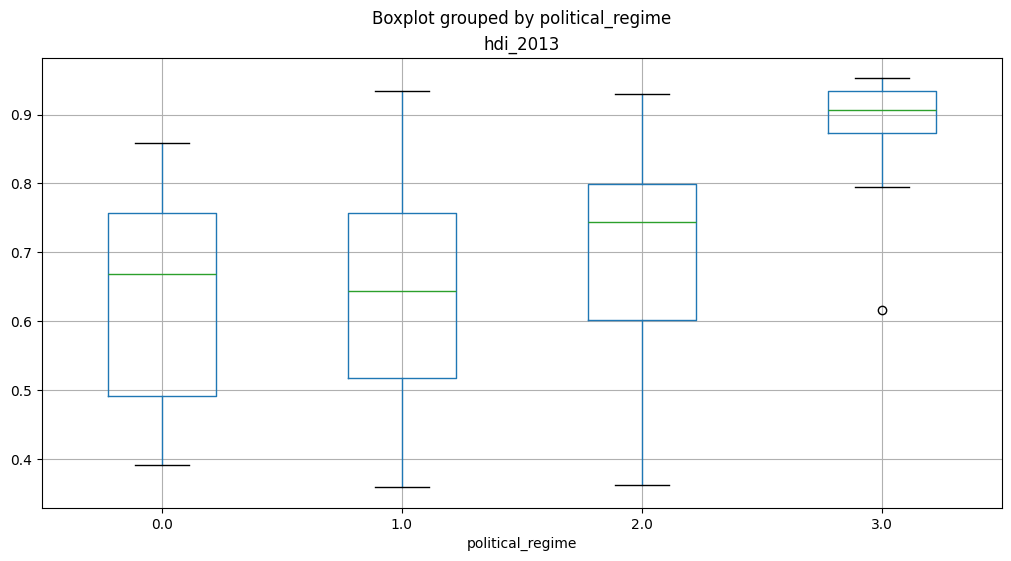

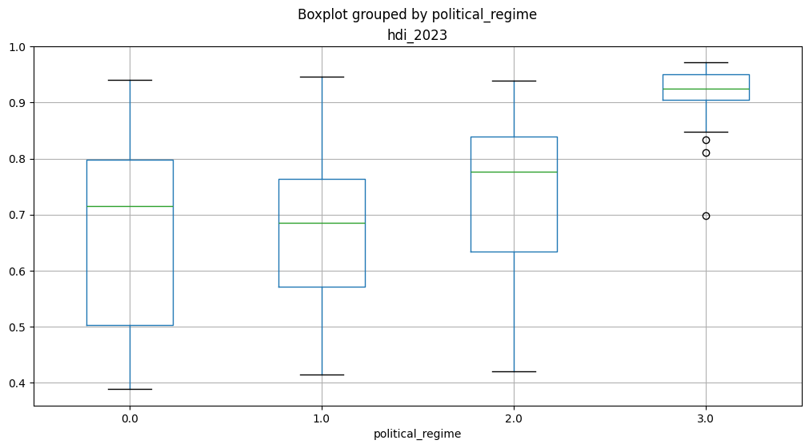

```python
for variable in ["life_expectancy", "population", "co2_emissions", "child_mortality", "hdi_2013", "hdi_2023"]:
    countries.boxplot(column=variable, by="political_regime", figsize=(12,6))
```

```python
from sklearn.datasets import load_iris
from sklearn.ensemble import RandomForestClassifier
from sklearn.metrics import classification_report, confusion_matrix
from sklearn.model_selection import train_test_split
clf = RandomForestClassifier()#construct the classifier
X_train, X_test, y_train, y_test = train_test_split(
	countries_cr[~countries["political_regime"].isna()],#On ne prend pas les pays pour lesquels "political_regime" vaut NaN, on pourra justement utiliser le modèle pour essayer de prédire pour ces pays
  countries[~countries["political_regime"].isna()]["political_regime"],
	train_size=0.7)
clf.fit(X_train, y_train)#train the classifier
y_pred = clf.predict(X_test)
print(confusion_matrix(y_test, y_pred))
print(classification_report(y_test, y_pred))
```

```
[[2 2 5 0]
 [4 7 5 0]
 [1 4 7 2]
 [0 0 3 9]]
              precision    recall  f1-score   support

         0.0       0.29      0.22      0.25         9
         1.0       0.54      0.44      0.48        16
         2.0       0.35      0.50      0.41        14
         3.0       0.82      0.75      0.78        12

    accuracy                           0.49        51
   macro avg       0.50      0.48      0.48        51
weighted avg       0.51      0.49      0.49        51
```

Globalement, le modèle n'est pas très bon puisqu'il se trompe pour plus de la moitié des cas. On peut voir que la classe sur laquelle le modèle s'en sort le mieux est "démocratie libérale", avec un f1-score de 78% avec quelques confusion avec la classe "démocratie éléctorale". Au contraire, il a du mal à détecter les autocraties fermées, qui sont minoritaires dans le jeu d'entraînement.

La première cause de ces mauvaises performances est que les variables choisies ne permettent pas assez de séparer les classes. Par ailleurs, le nombre de pays est assez faible ce qui rend l'apprentissage difficile.

```python
results = gpd.GeoDataFrame({"y_pred":y_pred,"y_true":y_test},index=X_test.index, geometry=countries.loc[X_test.index, "geometry"])
results
```

[output not shown]

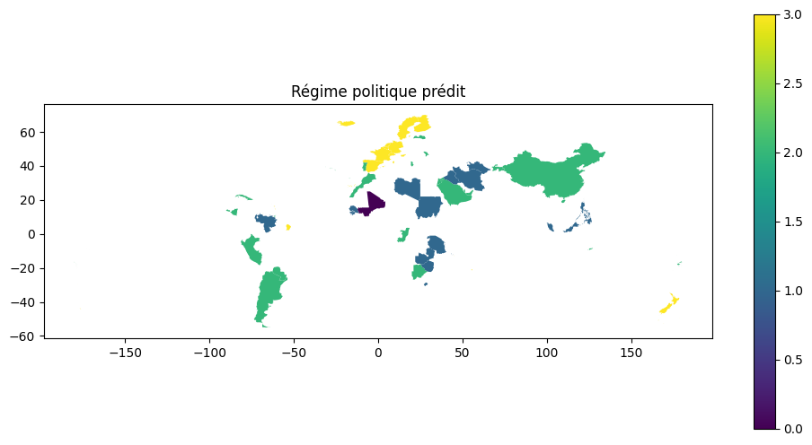

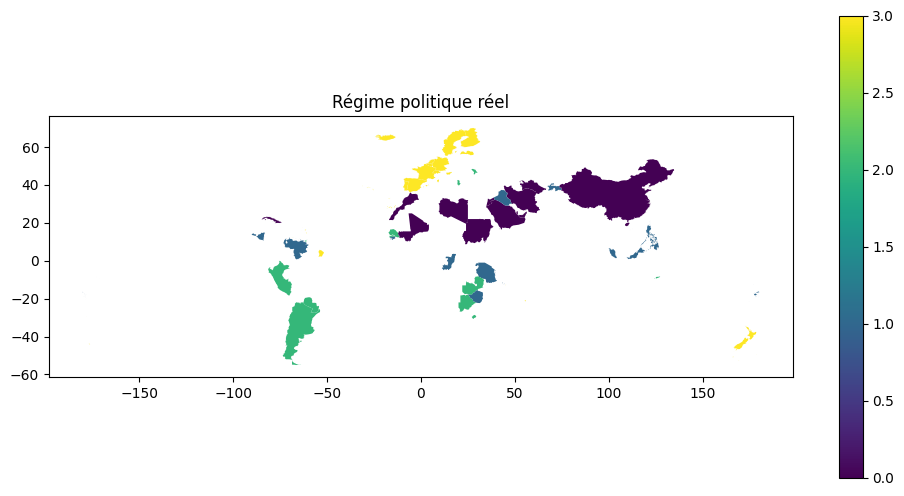

```python
results.plot(column="y_pred", figsize=(12,6), legend=True).set_title("Régime politique prédit")
results.plot(column="y_true", figsize=(12,6), legend=True).set_title("Régime politique réel")
```

On peut utiliser le modèle (même s'il n'est pas très bon) pour prédire le régime politique des pays pour lesquels on a pas de données

```python
predictions_pays_regimes_inconnus = gpd.GeoDataFrame(
    {"regime prédit":clf.predict(countries_cr[countries["political_regime"].isna()])},
    index=countries[countries["political_regime"].isna()].index,
    geometry=countries[countries["political_regime"].isna()].geometry
    )
predictions_pays_regimes_inconnus
```

| name | regime prédit | geometry |
| --- | --- | --- |
| Palestine | 1.0 | MULTIPOLYGON (((34.4812 31.58314, 34.52013 31.... |
| Brunei | 2.0 | MULTIPOLYGON (((115.14617 4.90852, 115.1468 4.... |
| Andorra | 3.0 | POLYGON ((1.70701 42.50278, 1.6975 42.49446, 1... |
| Belize | 2.0 | MULTIPOLYGON (((-89.19314 16.39263, -89.18435 ... |
| Bahamas | 3.0 | MULTIPOLYGON (((-72.99957 21.45171, -73.03366 ... |
| Kiribati | 2.0 | MULTIPOLYGON (((173.03826 1.34105, 173.02442 1... |
| Marshall Islands | 1.0 | MULTIPOLYGON (((168.10108 5.59931, 168.10133 5... |
| Grenada | 3.0 | MULTIPOLYGON (((-61.61294 12.21442, -61.60456 ... |
| Saint Vincent and the Grenadines | 3.0 | MULTIPOLYGON (((-61.194 13.03685, -61.20832 13... |
| Saint Lucia | 3.0 | POLYGON ((-60.88679 14.01008, -60.88296 13.980... |
| Dominica | 3.0 | POLYGON ((-61.36286 15.20181, -61.37409 15.204... |
| Antigua and Barbuda | 3.0 | MULTIPOLYGON (((-61.88362 17.04902, -61.87922 ... |
| Saint Kitts and Nevis | 3.0 | MULTIPOLYGON (((-62.59923 17.20295, -62.57844 ... |
| Tonga | 3.0 | MULTIPOLYGON (((-173.95637 -18.56732, -173.941... |
| Samoa | 3.0 | MULTIPOLYGON (((-172.20104 -13.59254, -172.197... |
| Tuvalu | 3.0 | MULTIPOLYGON (((179.19125 -8.54209, 179.20004 ... |
| Nauru | 3.0 | POLYGON ((166.93881 -0.49041, 166.95558 -0.497... |
| Micronesia (country) | 2.0 | MULTIPOLYGON (((163.02605 5.34089, 163.03045 5... |
| Palau | 3.0 | MULTIPOLYGON (((134.2715 7.07453, 134.27931 7.... |

#### BONUS: probabilités

```python
y_proba = clf.predict_proba(X_test)
y_proba
```

```
array([[0.12, 0.26, 0.5 , 0.12],
       [0.02, 0.05, 0.09, 0.84],
       [0.02, 0.65, 0.33, 0.  ],
       [0.01, 0.02, 0.09, 0.88],
       [0.  , 0.18, 0.1 , 0.72],
       [0.1 , 0.71, 0.19, 0.  ],
       [0.  , 0.08, 0.07, 0.85],
       [0.01, 0.02, 0.09, 0.88],
       [0.03, 0.29, 0.68, 0.  ],
       [0.14, 0.23, 0.63, 0.  ],
       [0.05, 0.34, 0.61, 0.  ],
       [0.06, 0.03, 0.41, 0.5 ],
       [0.01, 0.07, 0.86, 0.06],
       [0.01, 0.04, 0.72, 0.23],
       [0.21, 0.14, 0.63, 0.02],
       [0.31, 0.22, 0.37, 0.1 ],
       [0.  , 0.1 , 0.03, 0.87],
       [0.01, 0.17, 0.74, 0.08],
       [0.01, 0.24, 0.67, 0.08],
       [0.08, 0.25, 0.67, 0.  ],
       [0.07, 0.44, 0.47, 0.02],
       [0.48, 0.07, 0.23, 0.22],
       [0.39, 0.38, 0.18, 0.05],
       [0.03, 0.16, 0.71, 0.1 ],
       [0.53, 0.3 , 0.17, 0.  ],
       [0.02, 0.56, 0.39, 0.03],
       [0.6 , 0.31, 0.09, 0.  ],
       [0.  , 0.42, 0.44, 0.14],
       [0.42, 0.42, 0.16, 0.  ],
       [0.02, 0.75, 0.23, 0.  ],
       [0.01, 0.21, 0.56, 0.22],
       [0.4 , 0.26, 0.34, 0.  ],
       [0.12, 0.52, 0.36, 0.  ],
       [0.04, 0.44, 0.5 , 0.02],
       [0.08, 0.34, 0.48, 0.1 ],
       [0.03, 0.78, 0.19, 0.  ],
       [0.  , 0.08, 0.05, 0.87],
       [0.01, 0.  , 0.06, 0.93],
       [0.14, 0.59, 0.27, 0.  ],
       [0.  , 0.05, 0.11, 0.84],
       [0.37, 0.27, 0.35, 0.01],
       [0.06, 0.01, 0.15, 0.78],
       [0.01, 0.26, 0.72, 0.01],
       [0.04, 0.75, 0.21, 0.  ],
       [0.23, 0.61, 0.16, 0.  ],
       [0.01, 0.23, 0.75, 0.01],
       [0.26, 0.52, 0.21, 0.01],
       [0.03, 0.63, 0.34, 0.  ],
       [0.12, 0.08, 0.42, 0.38],
       [0.02, 0.57, 0.41, 0.  ],
       [0.06, 0.59, 0.35, 0.  ]])
```

Chaque ligne correspond aux probabilités données par le modèle pour les 4 classes.

```python
results[["proba_0", "proba_1", "proba_2", "proba_3"]] = y_proba
results
```

[output not shown]

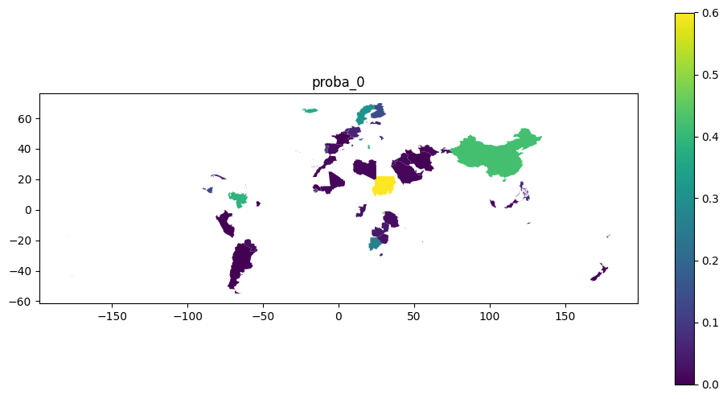

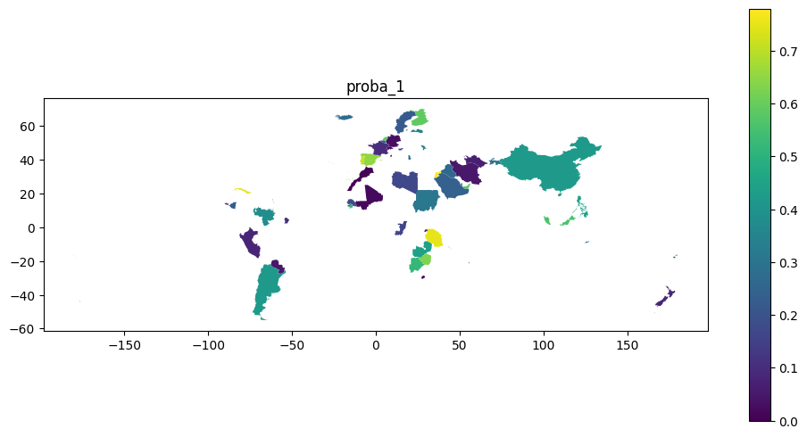

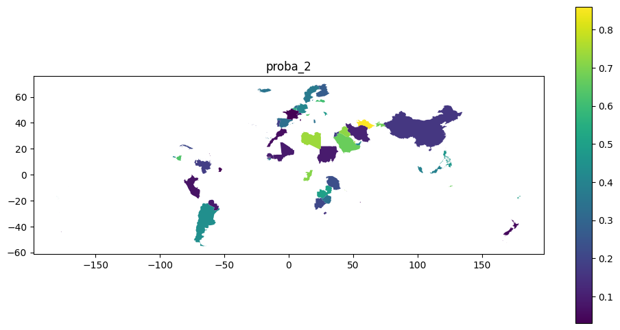

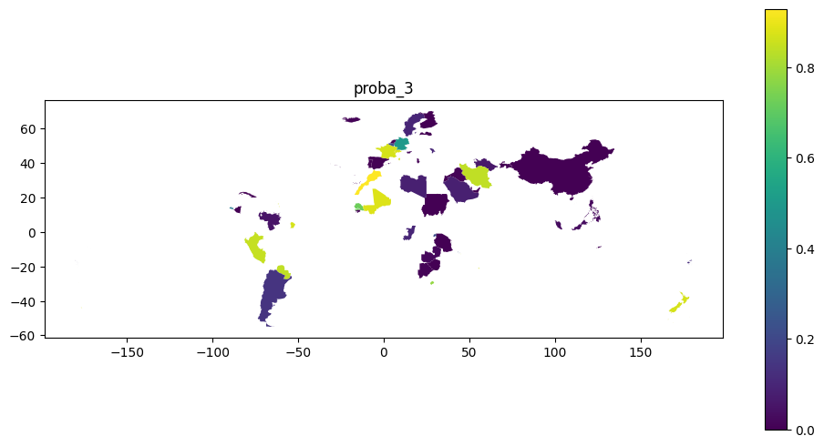

```python
for proba in ["proba_0", "proba_1", "proba_2", "proba_3"]:
    results.plot(column=proba, figsize=(12,6), legend=True).set_title(proba)
```